# 11 Introducción a la Probabilidad

2024-03-18

## Análisis de datos I (MAT1409)

## 4 Introducción a la Probabilidad

## Tema 4.1 Variables Aleatorias.

- Variable aleatoria(\(X\)): Es una variable cuyos valores son determinados por el resultado de un proceso aleatorio (existe incertidumbre.
- Variable numérica discreta: Es una variable aleatoria que tiene valores contables.
- Distribucion de probabilidad de masa.
- Variable numérica continua: Es una variable aleatoria que tiene un valores que se miden.
- Distribucion de probabilidad de densidad.
- Experimento: El proceso aleatorio de generar resultados de variables aleatorias.

## Tema 4.2 Evento y Espacio de probabilidad.

- Espacio de probabilidad (\(S\)): El conjunto de todos los posibles resultados de una variable aleatoria.
- Evento(\(E, A, B\)): Un resultado o un conjunto de resultados particulares de una variable aleatoria.
- Probabilidad \(P\), Probabilidad \(P(E_n)=p\) de un evento en particular.

## Tema 4.3 Axiomas de Probabilidad

- La probabilidad: es una medida del grado de creencia de una persona en la ocurrencia de un evento.
1. Axioma de la No Negatividad: \[ 0 \leq P(A) \leq 1 \quad \text{para todo evento } A. \]
2. Axioma de la Normalización (total): \[ P(S) = 1 \] Donde \(S\) es el espacio muestral.
3. Axioma de la Aditividad: \[ P(A \cup B) = P(A) + P(B) \quad \text{si } A \cap B = \emptyset \] Para eventos mutuamente excluyentes.

## Tema 4.4 Frecuencia relativa y probabilidad.

- La probabilidad de una varible se puede medir de forma empírica cuando se repite un experimiento \(n\) veces y se registra la frecuencia relativa de cada evento.
- A medida que \(n\) crece la frecuencia relativa de un evento tiende a acercarse a la probabilidad teórica de ese evento.

## Tema 4.5 Ejemplo:

| 0 | 1 |
| --- | --- |
| 0.6666667 | 0.3333333 |

## Tema 4.4 Frecuencia relativa y probabilidad (1/2).

| 0 | 1 |
| --- | --- |
| 0.56 | 0.44 |

## Tema 4.5 Reglas de probabilidad elementales

- Adición de eventos:

\[ P(A \cup B) = P(A \text{ o } B) = P(A) + P(B) - P(A \cap B) \]

Recuerda que, is \(A\) y \(B\) son mutuamente excluyentes: \(P(A \cap B)=P(A \text{ y } B)=0\)

- Multiplicacion de eventos:

\[ P(A \cap B) = P(A \text{ y } B) = P(A)*P(B)\], cuando \(A\) y \(B\) son independientes.

## Tema 4.6 Reglas de probabilidad elementales

- Dos eventos independientes no es lo mismo que mutuamente excluyentes.
- \(A\) and \(B\) son independientes si \(P(A \cap B) = P(A)\times P(B)\)
- \(A\) and \(B\) son mutuamente excluyentes si \(P(A \cap B) = P(A)\times P(B)=0\)

## Tema 4.7 Diagramas de Venn: Eventos Mutuamente Excluyentes

- Dos (o más) eventos mutuamente excluyentes, no tienen elementos comunes en el espacio muestral.

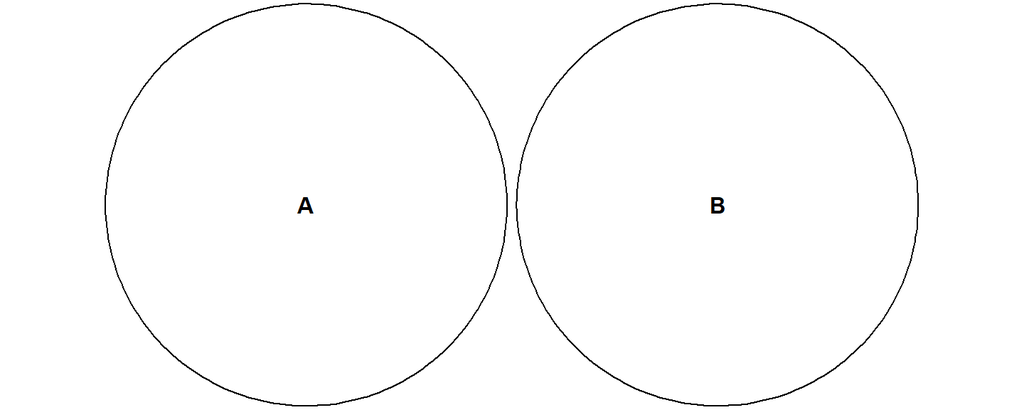

## Tema 4.7 Diagramas de Venn: Eventos Mutuamente Excluyentes

- Lanzamiento de una moneda.
- Lanzamiento de un dado.
- Colores de una luz de tráfico.
- Sexo de un recién nacido.
- Lluvioso o soleado.

## Tema 4.7 Diagramas de Venn: Eventos Independientes.

- Dos (o más) eventos independientes con elementos comunes en su espacio muestral:

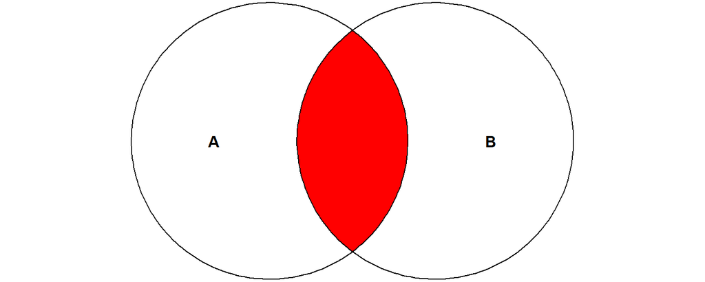

## Tema 4.8 Ejercicios (1/1)

- Experimento de lanzar un dado.
- Define el espacio muestral \(S\)
- Define el espacio muestral del evento \(A\): ocurra un número par (divisible entre 2 sin residuo).
- Define el espacio muestral del evento \(B\): ocurra un número impar (divisible entre 2 con residuo).
- Define el espacio muestral del evento \(C\): ocurra un número primo ( tiene exactamente dos divisores: 1 y el propio número, excluye el uno).

## Tema 4.8 Ejercicios (2/1)

- El espacio muestral:

\[ S = \{1, 2, 3, 4, 5, 6\} \]

- El evento \(A\), un número par:

\[ A = \{2, 4, 6\} \]

- El evento \(B\), un número impar:

\[ A = \{1, 3, 5\} \]

- El evento \(C\), un número primo:

\[ A = \{2, 3, 5\} \]

## Tema 4.8 Ejercicios (3/1)

Define los siguientes eventos:

- \(A \cup C\): el evento de que ocurra un número par o primo.
- \(B \cap C\): el evento de que ocurra un número impar y primo.
- \(A \cap B\): el evento de que ocurra un número par y impar.

## Tema 4.8 Ejercicios (4/1)

El evento de que ocurra un número par o primo:

\[ A \cup C = \{2, 3, 4, 5, 6\} \]

El evento de que ocurra un número impar y primo:

\[ B \cap C = \{3, 5\} \]

Si \(A\) y \(B\) son mutuamente excluyentes: \(A \cap B = \emptyset\); en otras palabras, un número par y un número impar no pueden ocurrir simultáneamente.

## Tema 4.8 Ejercicios (1/2)

Sea lanzada una moneda y un dado; sea el espacio muestral \(S\) consistente de los doce elementos: \[ S = \{H1, H2, H3, H4, H5, H6, T1, T2, T3, T4, T5, T6\} \]

Expresar explícitamente los siguientes eventos:

- \(A = \{\text{cara(H) y un número par aparecen}\}\).
- \(B = \{\text{aparece un número primo}\}\).
- \(C = \{\text{sol(T) y un número impar aparecen}\}\).

## Tema 4.8 Ejercicios (2/2)

- Ocurra \(A\) o \(B\).
- Ocurran \(B\) y \(C\).
- ¿Cuáles de los eventos \(A\), \(B\) y \(C\) son mutuamente excluyentes?

## Tema 4.8 Ejercicios (3/2)

- Cara y número par: \(A = \{H2, H4, H6\}\).
- Un número primo:

\(B = \{H2, H3, H5, T2, T3, T5\}\).

- sol(T) y un número impar aparecen:

\(C = \{T1, T3, T5\}\).

## Tema 4.8 Ejercicios (4/2)

- \(A\) o \(B\) = \(A \cup B\) = {H2, H4, H6, H3, H5, T2, T3, T5}.
- \(B\) y \(C\) = \(B \cap C\) = {T3, T5}.
- \(A\) y \(C\) son mutuamente excluyentes ya que \(A \cap C = \emptyset\).

## Tema 4.9 Probabilidad Condicional

- La probabilidad de que ocurra un evento \(A\) una vez que ha ocurrido \(E\), o
- La probabilidad condicional de \(A\) dado \(E\):

  \[ P(A | E) = \frac{P(A \cap E)}{P(E)} \]

## Tema 4.9 Probabilidad Condicional

- Lanza un par de dados justos.

  \(E = \{ \text{la suma es 6} \} = \{(1,5), (2,4), (3,3), (4,2), (5,1)\}\)

  y \(A = \{\text{2 en al menos un dado}\} = \{(2,4), (4,2)\}\),
- Encuentra la probabilidad de que salga un 2 dado que la suma de los dados es 6 \(P(A | E)\).
- \(E\) consta de cinco elementos y dos de ellos, (2,4) y (4,2), pertenecen a \(A\):

  \(A \cap E = \{(2,4), (4,2)\}\). Entonces \(P(A | E) = 2/5\).

## Revisión

```
## Versión: 19/03/2024
```

## Bibliografía

## Bibliografía

- Dodge, Y. (2008). The concise encyclopedia of statistics. Springer Science & Business Media.
- Business Mathematics.(2023).SBPD https://www.google.com.mx/books/edition/Business_Mathematics/oRLFEAAAQBAJ
- Smith, G. (2015). *Essential statistics, regression, and econometrics.*
- Spiegel, M. R., Srinivasan, R. A., & Schiller, J. J. (2000). Schaum’s outline of theory and problems of probability and statistics. Erlangga.